# Oxford Happiness Questionnaire

coop711

2024-04-19

옥스포드 행복 설문지 실험결과를 분석한다. 이 실험에는 두 가지 목적이 있다. 첫째는 있는 그대로 옥스포드 행복 설문지로 측정하는 여러분의 행복 수준은 어느 정도인지, 둘째는 영문판으로 응답할 때와 국문판으로 응답할 때 어떤 차이가 있는지, 특히 응답에 소요되는 시간을 측정해 보았다.

## Red, Black을 잘못 표시한 사람들

랜덤화출석부에 있는 Red, Black 과 실제 구글설문에 올린 Red, Black 이 다른 사람들의 수효는 세명입니다. Red를 Black 이라고 한 사람이 1명, Black 을 Red 라고 한 사람이 2명입니다.

|  | Red(옥스포드행복설문지) | Black(옥스포드행복설문지) |
| --- | --- | --- |
| **Red(랜덤화출석부)** | 373 | 1 |
| **Black(랜덤화출석부)** | 2 | 376 |

## 행복 점수 비교

국문 설문지와 영문 설문지의 행복점수를 비교한다. 행복점수 단계별로 비교했을 때나 기초통계로 비교했을 때나 국문 설문지로 작성한 그룹 (Red)의 행복점수가 높게 나온다. 이는 통계적으로 매우 매우 유의한 수준이다.

### `summary()`

- **국문**:

  | Min. | 1st Qu. | Median | Mean | 3rd Qu. | Max. |
  | --- | --- | --- | --- | --- | --- |
  | 2.103 | 3.483 | 4 | 4.042 | 4.586 | 5.655 |

- **영문**:

  | Min. | 1st Qu. | Median | Mean | 3rd Qu. | Max. |
  | --- | --- | --- | --- | --- | --- |
  | 2.103 | 3.414 | 3.69 | 3.836 | 4.172 | 5.345 |

### `table()`

|  | 행복하지 않다 | 다소 행복하지 않다 | 그저 그렇다 | 꽤 행복하다 | 매우 행복하다 | 계 |
| --- | --- | --- | --- | --- | --- | --- |
| **국문** | 0 | 23 | 163 | 156 | 33 | 375 |
| **영문** | 0 | 6 | 244 | 111 | 16 | 377 |
| **계** | 0 | 29 | 407 | 267 | 49 | 752 |

Pearson’s Chi-squared test with simulated p-value (based on 2000 replicates): `.`

| Test statistic | df | P value |
| --- | --- | --- |
| 39.56 | NA | 0.0004998 * * * |

### 백분율(%)

| 행복하지 않다 | 다소 행복하지 않다 | 그저 그렇다 | 꽤 행복하다 | 매우 행복하다 | 계 |
| --- | --- | --- | --- | --- | --- |
| 0.0 | 3.9 | 54.1 | 35.5 | 6.5 | 100.0 |

### `geom_boxplot()`

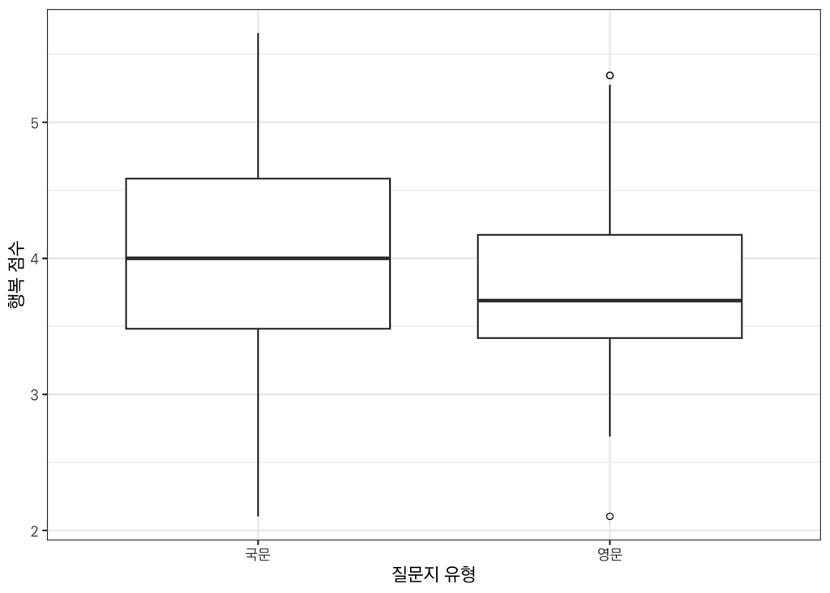

### `t.test()` on means

Welch Two Sample t-test: `Scores` by `group`

| Test statistic | df | P value | Alternative hypothesis | mean in group 국문 | mean in group 영문 |
| --- | --- | --- | --- | --- | --- |
| 4.484 | 706.2 | 4.266e-06 * * * | greater | 4.042 | 3.836 |

## 소요시간 비교

초 단위로 측정한 소요시간에서는 오전, 오후를 잘못 쓴다거나 시작 시간이 제출 시간보다 늦게 입력한 사람들이 있고, 과도하게 (한 시간) 이상 소요된 것으로 나오는 사람들이 있어서 일일이 찾아서 수정하였고, 한 시간 이상은 사실상 설문지를 작성하다가 다른 일을 하고 다시 돌아와 마치는 과정을 의미하는 것으로 판단하여 NA 로 처리하였다. 소요 시간에 있어서도 국문과 영문에는 통계적으로 유의한 수준의 차이가 관찰되지 않았다.

평균적으로 34.6초, 즉 0분 35초정도 국문 질문지에 더 빨리 응답한다. 소요시간의 중위값을 비교해 보면 34 초, 약 0분 34초 만큼 국문 질문지에 더 빨리 응답하지만 통계적으로 유의한 수준은 아니다.

### `summary()`

- **국문**:

  | Min. | 1st Qu. | Median | Mean | 3rd Qu. | Max. | NA’s |
  | --- | --- | --- | --- | --- | --- | --- |
  | 6 | 126 | 170 | 263.1 | 251.2 | 3330 | 39 |

- **영문**:

  | Min. | 1st Qu. | Median | Mean | 3rd Qu. | Max. | NA’s |
  | --- | --- | --- | --- | --- | --- | --- |
  | 21 | 107 | 204 | 297.7 | 348 | 2358 | 40 |

### `geom_boxplot()`

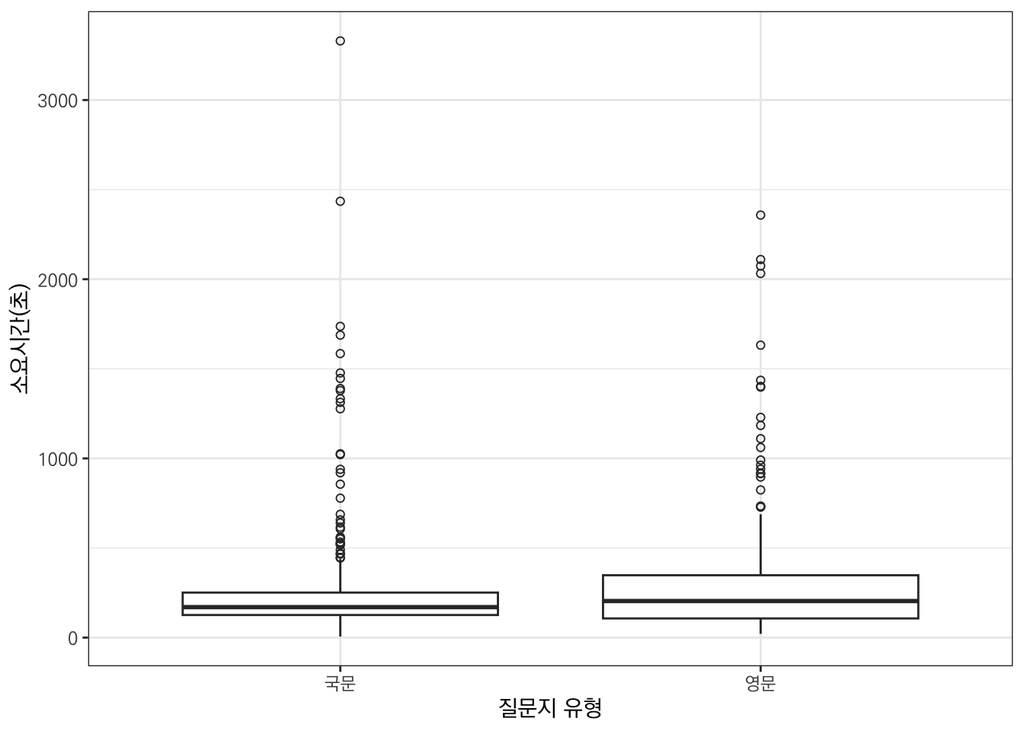

### `t.test()` on means

Welch Two Sample t-test: `as.numeric(Duration)` by `group`

| Test statistic | df | P value | Alternative hypothesis | mean in group 국문 | mean in group 영문 |
| --- | --- | --- | --- | --- | --- |
| -1.375 | 669.8 | 0.1697 | two.sided | 263.1 | 297.7 |

## 일 단위 마감 시간으로부터 제출 시간의 분포

### 분포표

일 단위

|  | [0,1] | (1,2] | (2,3] | (3,4] | (4,5] | (5,6] | (6,7] | (7,8] | (8,9] | (9,10] | (10,11] | (11,12] | (12,13] | (13,14] |
| --- | --- | --- | --- | --- | --- | --- | --- | --- | --- | --- | --- | --- | --- | --- |
| **국문** | 138 | 29 | 22 | 22 | 14 | 8 | 13 | 46 | 21 | 19 | 9 | 8 | 8 | 18 |
| **영문** | 145 | 38 | 18 | 25 | 10 | 9 | 10 | 41 | 11 | 18 | 7 | 8 | 21 | 16 |

Pearson’s Chi-squared test: `.`

| Test statistic | df | P value |
| --- | --- | --- |
| 12.72 | 13 | 0.4697 |

### 막대그래프

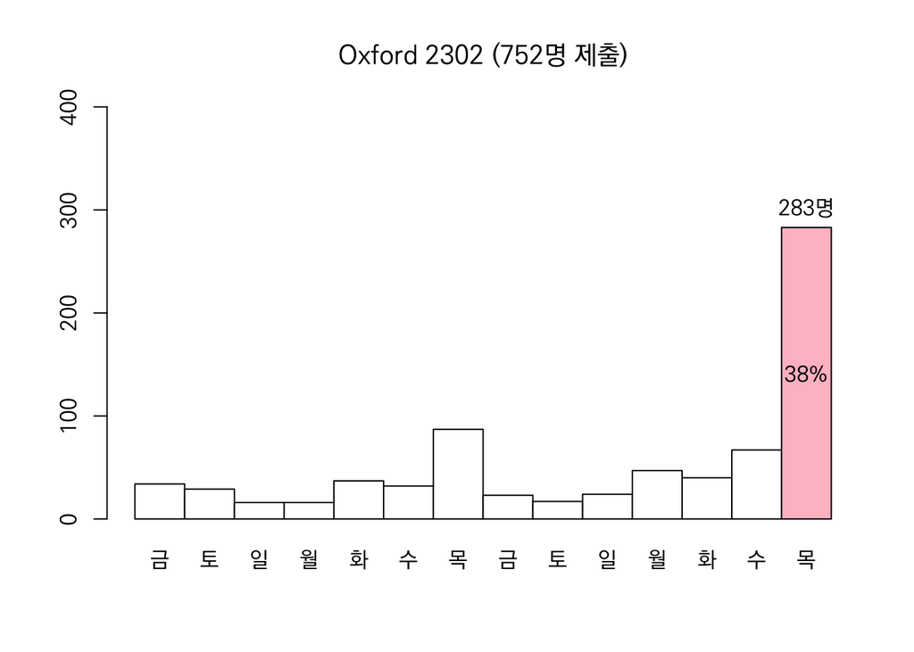

### Mosaic Plot

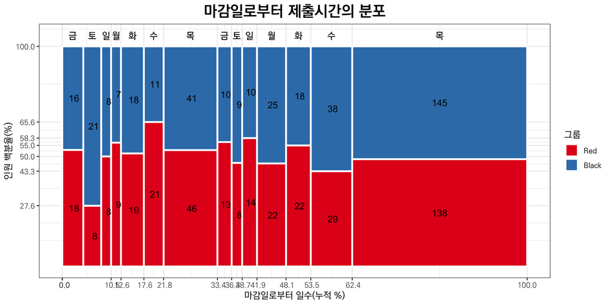